# Health Care System

## Statistics for the Simulation's Project

In this notebook it's possible to observe some statistics related to the **Simulation's Project**. At the end of each simulation, we extracted a *txt* file in which there are three different parameters: *Room, Time and WaitingTime*.

```python
import pandas as pd
import matplotlib
import numpy as np
import matplotlib.pyplot as plt
import os
```

```python
df_update = pd.read_csv('waitingTimeDatasets.txt', delimiter = ',')
df_statistics = pd.read_csv('untreatedPatients.txt', delimiter = ',')
```

```python
path = os.getcwd()
path = path + '\\old_datasets'
os.chdir(path)
```

```python
df_old = pd.read_csv('waitingTimeDatasets - 09-10.txt', delimiter = ',')
```

```python
df = df_old
```

```python
df
```

|  | Room | Time | WaitingTime |
| --- | --- | --- | --- |
| 0 | White | 84.823170 | 37.523788 |
| 1 | White | 279.642569 | 22.419077 |
| 2 | White | 440.500719 | 18.149885 |
| 3 | White | 609.151788 | 29.682892 |
| 4 | White | 1028.051177 | 15.493822 |
| ... | ... | ... | ... |
| 130 | Red | 760.891764 | 19.795974 |
| 131 | Red | 817.983605 | 41.448965 |
| 132 | Red | 835.394052 | 39.005356 |
| 133 | Red | 993.661191 | 20.580664 |
| 134 | Red | 1195.650270 | 24.581175 |

135 rows × 3 columns

### Plot for each Room

In this section we report the plots containing the data for each room.

```python
white_room_data = df[df['Room'] == 'White']
green_room_data = df[df['Room'] == 'Green']
blue_room_data = df[df['Room'] == 'Blue']
orange_room_data = df[df['Room'] == 'Orange']
red_room_data = df[df['Room'] == 'Red']
```

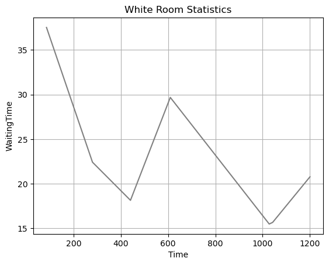

```python
plt.plot(white_room_data['Time'], white_room_data['WaitingTime'], color = 'gray')
plt.title('White Room Statistics')
plt.xlabel('Time')
plt.ylabel('WaitingTime')
plt.grid(True)
plt.show()
```

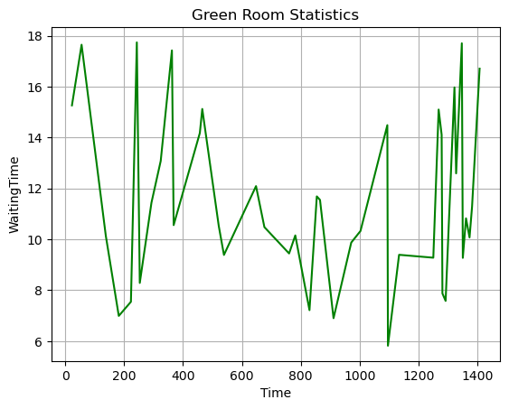

```python
plt.plot(green_room_data['Time'], green_room_data['WaitingTime'], color = 'green')
plt.title('Green Room Statistics')
plt.xlabel('Time')
plt.ylabel('WaitingTime')
plt.grid(True)
plt.show()
```

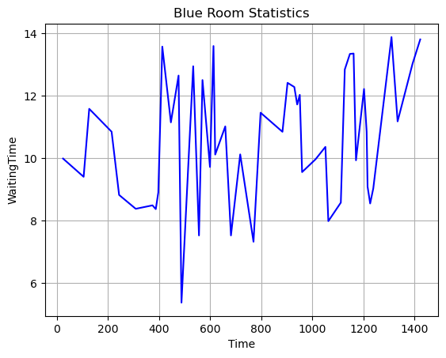

```python
plt.plot(blue_room_data['Time'], blue_room_data['WaitingTime'], color = 'blue')
plt.title('Blue Room Statistics')
plt.xlabel('Time')
plt.ylabel('WaitingTime')
plt.grid(True)
plt.show()
```

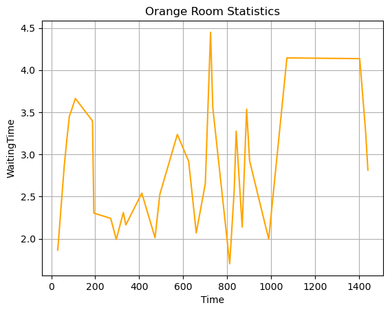

```python
plt.plot(orange_room_data['Time'], orange_room_data['WaitingTime'], color = 'orange')
plt.title('Orange Room Statistics')
plt.xlabel('Time')
plt.ylabel('WaitingTime')
plt.grid(True)
plt.show()
```

[figure not shown]

```python
plt.plot(white_room_data['Time'], white_room_data['WaitingTime'], color = 'red')
plt.title('Red Room Statistics')
plt.xlabel('Time')
plt.ylabel('WaitingTime')
plt.grid(True)
plt.show()
```

### Comparison between rooms

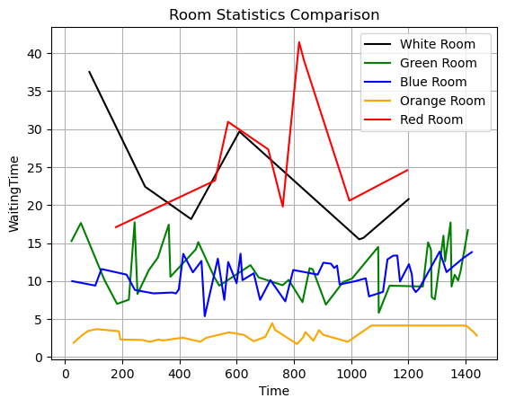

```python
# Crea un plot per confrontare tutte le stanze
plt.plot(white_room_data['Time'], white_room_data['WaitingTime'], label='White Room', color='black')
plt.plot(green_room_data['Time'], green_room_data['WaitingTime'], label='Green Room', color='green')
plt.plot(blue_room_data['Time'], blue_room_data['WaitingTime'], label='Blue Room', color='blue')
plt.plot(orange_room_data['Time'], orange_room_data['WaitingTime'], label='Orange Room', color='orange')
plt.plot(red_room_data['Time'], red_room_data['WaitingTime'], label='Red Room', color='red')

plt.title('Room Statistics Comparison')
plt.xlabel('Time')
plt.ylabel('WaitingTime')
plt.grid(True)
plt.legend()
plt.show()
```

Looking at the graph, we can come to the following considerations.

The **Green room** has a fairly stable waiting time, with some peaks, but which remains constant for medium-low values. Therefore, it is possible to conclude that the workload was managed efficiently.

The **Blue room** has fairly stable waiting times, so it was not possible to observe an overload of resources.

The **Orange room** has low and stable waiting times. There are no different fluctuations, so this is less used but certainly very efficient.

All this data was collected knowing the following information about resources:

- the nurses specialized for the white room are 4
- the nurses who take care of the patients in the green room are 3
- the nurses who manage the patients in the blue room are 2

### Average Treatment Time per Room

First we calculated the average time patients spend in each room, to understand which rooms process patients the fastest.

```python
df.groupby('Room')['WaitingTime'].mean()
```

```
Room
Blue      10.597028
Green     11.538203
Orange     2.835231
Red       27.114881
White     22.818608
Name: WaitingTime, dtype: float64
```

### Distribution of treatment times

In this section we report a histogram for each room to visualize the distribution of processing times and see if there are queues or significant delays in some rooms.

#### White Room

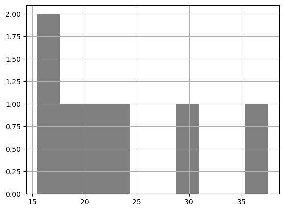

```python
df[df['Room'] == 'White']['WaitingTime'].hist(color='gray')
```

#### Green Room

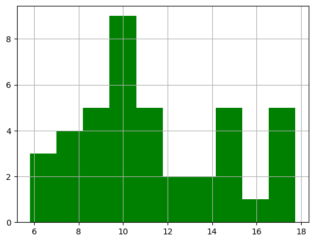

```python
df[df['Room'] == 'Green']['WaitingTime'].hist(color='green')
```

#### Blue Room

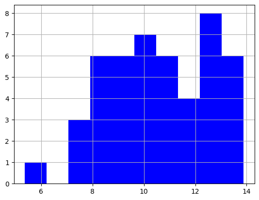

```python
df[df['Room'] == 'Blue']['WaitingTime'].hist(color='blue')
```

#### Orange Room

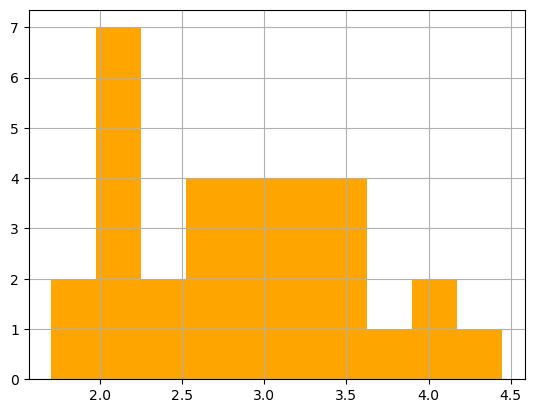

```python
df[df['Room'] == 'Orange']['WaitingTime'].hist(color='orange')
```

#### Red Room

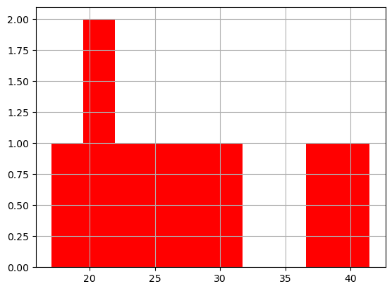

```python
df[df['Room'] == 'Red']['WaitingTime'].hist(color='red')
```

### Total Room Usage Time (Cumulative)

Adds the total usage times for each room to understand which rooms were used the most during the simulated period.

```python
result = df.groupby('Room')['WaitingTime'].sum()
result
```

```
Room
Blue      498.060309
Green     473.066333
Orange     87.892165
Red       244.033931
White     159.730256
Name: WaitingTime, dtype: float64
```

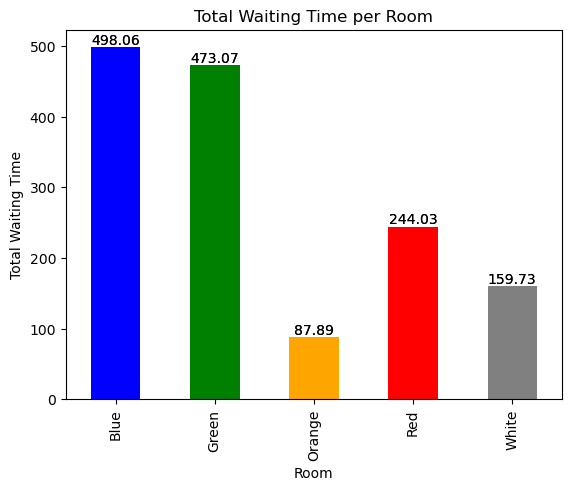

```python
result.plot(kind='bar', color='skyblue')

colors = ['blue', 'green', 'orange', 'red', 'grey']

ax = result.plot(kind='bar', color=colors)

for p in ax.patches:
    ax.annotate(f'{p.get_height():.2f}', (p.get_x() + p.get_width() / 2, p.get_height()),
                ha='center', va='bottom')

# Aggiungi titolo e etichette
plt.title('Total Waiting Time per Room')
plt.xlabel('Room')
plt.ylabel('Total Waiting Time')

plt.show()
```

### Room Comparison

Compare average treatment time and workload between different rooms (White, Green, etc.) to identify any imbalances in the system.

```python
df.pivot_table(index='Room', values='WaitingTime', aggfunc=['mean', 'sum'])
```

| Room | mean WaitingTime | sum WaitingTime |
| --- | --- | --- |
| Blue | 10.597028 | 498.060309 |
| Green | 11.538203 | 473.066333 |
| Orange | 2.835231 | 87.892165 |
| Red | 27.114881 | 244.033931 |
| White | 22.818608 | 159.730256 |

### Operation Time Trend

View how processing time changes over time to see if there are periods of overload or inefficiency.

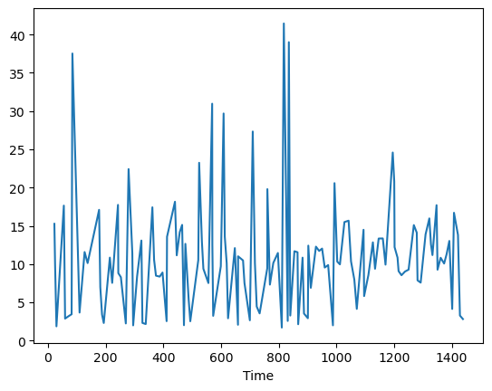

```python
df.groupby('Time')['WaitingTime'].mean().plot()
```

### Resource overload analysis.

In our emergency room scenario, this means looking at when rooms or resources (such as nurses, equipment, or rooms themselves) are overused or can't keep up with demand.

#### Peak utilization assessment

We can analyze peak utilization of a resource by looking at times when values (e.g., usage or treatment times) are higher than average or exceed a certain threshold.

We then need to

1. Calculate the average usage time for each room and see if there are times when the times are significantly higher than average.
2. Display the peaks with a graph to visually identify periods when the resource is overloaded:

##### White Room

```python
mean_time_white = df[df['Room'] == 'White']['WaitingTime'].mean()

# Trova le occorrenze in cui il valore supera una soglia, ad esempio 1.5 volte la media
high_usage_white = df[(df['Room'] == 'White') & (df['WaitingTime'] > 1.5 * mean_time_white)]

# Visualizza i momenti di sovraccarico
print(high_usage_white)
```

```
    Room      Time  WaitingTime
0  White  84.82317    37.523788
```

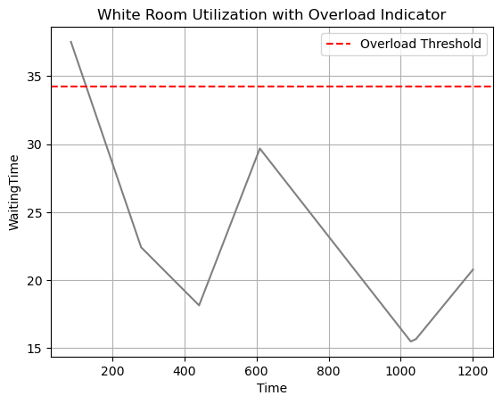

```python
plt.plot(white_room_data['Time'], white_room_data['WaitingTime'], color='gray')
plt.axhline(y=1.5 * mean_time_white, color='red', linestyle='--', label='Overload Threshold')
plt.title('White Room Utilization with Overload Indicator')
plt.xlabel('Time')
plt.ylabel('WaitingTime')
plt.legend()
plt.grid(True)
plt.show()
```

##### Green Room

```python
mean_time_white = df[df['Room'] == 'Green']['WaitingTime'].mean()

# Trova le occorrenze in cui il valore supera una soglia, ad esempio 1.5 volte la media
high_usage_white = df[(df['Room'] == 'Green') & (df['WaitingTime'] > 1.5 * mean_time_white)]

# Visualizza i momenti di sovraccarico
print(high_usage_white)
```

```
     Room         Time  WaitingTime
8   Green    55.158285    17.644512
12  Green   242.895179    17.737835
16  Green   362.185431    17.422477
42  Green  1347.502720    17.702213
```

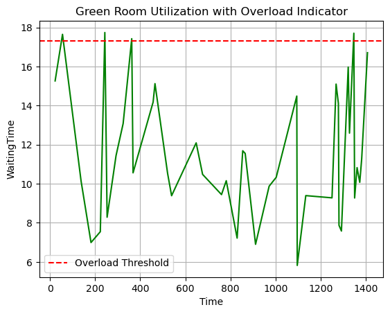

```python
plt.plot(green_room_data['Time'], green_room_data['WaitingTime'], color='green')
plt.axhline(y=1.5 * mean_time_white, color='red', linestyle='--', label='Overload Threshold')
plt.title('Green Room Utilization with Overload Indicator')
plt.xlabel('Time')
plt.ylabel('WaitingTime')
plt.legend()
plt.grid(True)
plt.show()
```

##### Blue Room

```python
mean_time_white = df[df['Room'] == 'Blue']['WaitingTime'].mean()

# Trova le occorrenze in cui il valore supera una soglia, ad esempio 1.5 volte la media
high_usage_white = df[(df['Room'] == 'Blue') & (df['WaitingTime'] > 1.5 * mean_time_white)]

# Visualizza i momenti di sovraccarico
print(high_usage_white)
```

```
Empty DataFrame
Columns: [Room, Time, WaitingTime]
Index: []
```

[figure not shown]

```python
plt.plot(green_room_data['Time'], green_room_data['WaitingTime'], color='blue')
plt.axhline(y=1.5 * mean_time_white, color='red', linestyle='--', label='Overload Threshold')
plt.title('Blue Room Utilization with Overload Indicator')
plt.xlabel('Time')
plt.ylabel('WaitingTime')
plt.legend()
plt.grid(True)
plt.show()
```

##### Orange Room

```python
mean_time_white = df[df['Room'] == 'Orange']['WaitingTime'].mean()

# Trova le occorrenze in cui il valore supera una soglia, ad esempio 1.5 volte la media
high_usage_white = df[(df['Room'] == 'Orange') & (df['WaitingTime'] > 1.5 * mean_time_white)]

# Visualizza i momenti di sovraccarico
print(high_usage_white)
```

```
       Room        Time  WaitingTime
113  Orange  723.991359     4.447654
```

[figure not shown]

```python
plt.plot(green_room_data['Time'], green_room_data['WaitingTime'], color='orange')
plt.axhline(y=1.5 * mean_time_white, color='red', linestyle='--', label='Overload Threshold')
plt.title('Orange Room Utilization with Overload Indicator')
plt.xlabel('Time')
plt.ylabel('WaitingTime')
plt.legend()
plt.grid(True)
plt.show()
```

##### Red Room

```python
mean_time_white = df[df['Room'] == 'Red']['WaitingTime'].mean()

# Trova le occorrenze in cui il valore supera una soglia, ad esempio 1.5 volte la media
high_usage_white = df[(df['Room'] == 'Red') & (df['WaitingTime'] > 1.5 * mean_time_white)]

# Visualizza i momenti di sovraccarico
print(high_usage_white)
```

```
    Room        Time  WaitingTime
131  Red  817.983605    41.448965
```

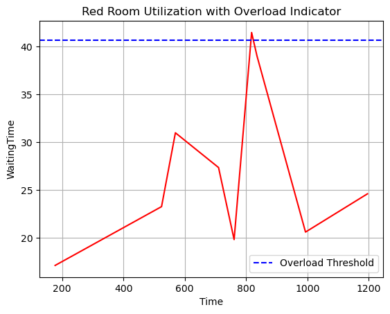

```python
plt.plot(red_room_data['Time'], red_room_data['WaitingTime'], color='red')
plt.axhline(y=1.5 * mean_time_white, color='blue', linestyle='--', label='Overload Threshold')
plt.title('Red Room Utilization with Overload Indicator')
plt.xlabel('Time')
plt.ylabel('WaitingTime')
plt.legend()
plt.grid(True)
plt.show()
```

### Identifying overloaded rooms

We can identify which rooms are more frequently overloaded than others by comparing the total usage time or the number of overload peaks.

The steps to follow are:

1. Calculate the total usage time for each room and see which resource was used the most.
2. Calculate the frequency of overloads: count how many times each room exceeded an overload threshold (for example, 1.5 times the average):

```python
total_usage_per_room = df.groupby('Room')['WaitingTime'].sum()
print(total_usage_per_room)
```

```
Room
Blue      498.060309
Green     473.066333
Orange     87.892165
Red       244.033931
White     159.730256
Name: WaitingTime, dtype: float64
```

```python
def count_overloads(room_name, threshold_factor):
    mean_time = df[df['Room'] == room_name]['WaitingTime'].mean()
    overloads = df[(df['Room'] == room_name) & (df['WaitingTime'] > threshold_factor * mean_time)]
    return len(overloads)

overload_counts = {room: count_overloads(room, 1.5) for room in df['Room'].unique()}
print(overload_counts)
```

```
{'White': 1, 'Green': 4, 'Blue': 0, 'Orange': 1, 'Red': 1}
```

### Comparison of rooms over time:

In this section we report a graph that compares the resource usage over time between different rooms can help you identify which rooms are most often overloaded.

```python
threshold_value = df['WaitingTime'].mean() * 1.5
```

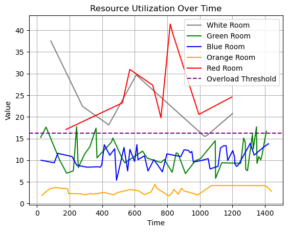

```python
plt.plot(white_room_data['Time'], white_room_data['WaitingTime'], label='White Room', color='gray')
plt.plot(green_room_data['Time'], green_room_data['WaitingTime'], label='Green Room', color='green')
plt.plot(blue_room_data['Time'], blue_room_data['WaitingTime'], label='Blue Room', color='blue')
plt.plot(orange_room_data['Time'], orange_room_data['WaitingTime'], label='Orange Room', color='orange')
plt.plot(red_room_data['Time'], red_room_data['WaitingTime'], label='Red Room', color='red')
plt.axhline(y=threshold_value, color='purple', linestyle='--', label='Overload Threshold')
plt.title('Resource Utilization Over Time')
plt.xlabel('Time')
plt.ylabel('Value')
plt.legend()
plt.grid(True)
plt.show()
```

In the graph, we clearly see that:

- Overload in the White and Red Rooms: These rooms frequently exceed the overload threshold, suggesting the need for additional resources or reprioritization.
- Good management in the Green and Blue Rooms: These rooms show stable utilization and do not appear to suffer from significant overloads.
- Underutilized Orange Room: The Orange Room may have too many resources dedicated compared to the actual demand, which may indicate wasted capacity.

### Percentage of patients treated within an acceptable time

This KPI measures the percentage of patients treated within an acceptable time.

```python
white_treated = white_room_data[white_room_data['WaitingTime'] <= 36].shape[0]
total_white_patients = white_room_data.shape[0]

green_treated = green_room_data[green_room_data['WaitingTime'] <= 16].shape[0]
total_green_patients = green_room_data.shape[0]

blue_treated = blue_room_data[blue_room_data['WaitingTime'] <= 12].shape[0]
total_blue_patients = blue_room_data.shape[0]

orange_treated = orange_room_data[orange_room_data['WaitingTime'] <= 4].shape[0]
total_orange_patients = orange_room_data.shape[0]
```

```python
percentage_white_treated = (white_treated / total_white_patients) * 100
print(f'Percentage of White Room patients treated within 36 minutes: {percentage_white_treated}%')

percentage_green_treated = (green_treated / total_green_patients) * 100
print(f'Percentage of Green Room patients treated within 16 minutes: {percentage_green_treated}%')

percentage_blue_treated = (blue_treated / total_blue_patients) * 100
print(f'Percentage of Blue Room patients treated within 12 minutes: {percentage_green_treated}%')

percentage_blue_treated = (orange_treated / total_orange_patients) * 100
print(f'Percentage of Orange Room patients treated within 4 minutes: {percentage_green_treated}%')
```

[output not shown]

### Number of untreated patients

This KPI measures the number of patients who do not receive care by the time the emergency room closes.

```python
df = df_statistics
```

```python
acceptanceWaiting = df['Value'][0]
waitingRoom = df['Value'][1]
totPatients = df['Value'][2]
```

```python
non_managed_patients = acceptanceWaiting+waitingRoom
```

```python
percentage_not_managed = (non_managed_patients / totPatients) * 100
print(f'Percentuale di pazienti non gestiti: {percentage_not_managed}%')
```

```
Percentuale di pazienti non gestiti: 20.0%
```